# Casque antibruit actif

**Capacité numérique**. : Représenter, à l’aide d’un langage de programmation, la somme de deux signaux sinusoïdaux périodiques synchrones en faisant varier la phase à l'origine

Nathan p 418

[figure not shown]

**Question 1:** Expliquer brièvement ce que permet de réaliser le code décrit dans le doc.2.

- On appelle S$_{1}$ la source du bruit intérieur.

Le signal du bruit intérieur a pour expression:

> s$_{1}$(t)= A$_{1}$ x cos($\frac{2\pi}{T}$t)  
> Sa phase à l'origine $\varphi$ est nulle.

Les deux sources S$_{1}$ et S$_{2}$ sont synchrones de période T.

- On appelle S$_{2}$ la source du second signal: l'antibruit.

Le signal de l'antibruit a pour expression:

> Soit s$_{2}$(t)= a x cos($\frac{2\pi}{T}$t+ $\varphi$ )  
> Sa phase à l'origine est $\varphi$.

On appelle également $\varphi$ le déphasage de S$_{1}$ par rapport à S$_{2}$

```python
import matplotlib.pyplot as plt
%matplotlib inline
import numpy as np
```

```python
#Initialisation des constantes
T=1 #la période vaut 1 ms
```

**Question 2:** Quelle est la fréquence du son reçu par le micro? Est-il audible par l'homme?

fréquence = 1/T soit 1000 Hz. C'est supérieur à 20Hz. le son est donc audible par l'oreille humaine.

```python
A1= float(input('Amplitude du signal 1: A1 = '))
A2= float(input('Amplitude du signal 2: A2 = '))
```

```
Amplitude du signal 1: A1 = 2
Amplitude du signal 2: A2 = 1
```

```python
#On souhaite faire varier la variable t (temps) entre 0 et 4 ms
# Pour cela , on crée un tableau de 4000 valeurs réparties de 0 à 4 pour l'axe des abscisses
t=np.linspace(0,4,4000)
```

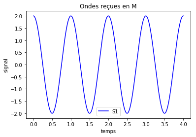

```python
#Création d'un tableau contenant les valeurs de s1(t)
s1=[]
for i in range(len(t)):
    s1.append(A1*np.cos(2*np.pi*t[i]/T))

# Affichage de s1(t)
plt.xlabel("temps") #abscisse
plt.ylabel("signal") #ordonnée
plt.plot(t,s1,'b-',label='S1') # Tracé d'une ligne bleue b-
plt.title("Ondes reçues en M")
plt.legend()
plt.show()
```

**Question 3:** En vous appuyant sur le modèle précédent, compléter le code pour faire afficher s$_{2}$(t), pour des valeurs de déphasage $\varphi$ prenant notamment les valeurs 0, $\pi$/2 et $\pi$. Vous modeliserez s$_{2}$(t) par une ligne rouge : r-. **Question 4:** Lorsque deux ondes de même nature (synchrone et cohérente) se croisent, leurs élogations s'additionnent. On dit qu'elles interfèrent. Créer une fonction onde résultante s(t) = s$_{1}$(t) + s$_{2}$(t). La faire afficher sur le même graphique. Vous la modeliserez par une ligne verte : g-. **Données:** en python la valeur de $\pi$ est obtenue par le code suivant : `np.pi` grâce à la bibliothèque numpy. Vous pouvez créer une cellule de code supplémentaire pour chaque tracé (à l'aide du bouton +).

**Question 5:** Exécuter le code pour étudier l'influence de la phase à l'origine $\varphi$ du signal s$_{2}$(t) sur la somme des deux signaux notamment lorsqu'elle vaut 0, $\pi$/2 et $\pi$.

**Question 6:** De même, étudier l'influence des amplitudes des signaux s$_{1}$(t) et s$_{2}$(t) sur leur somme lorsque la phase à l'origine $\varphi$ du signal s$_{2}$(t) vaut 0, $\pi$/2 et $\pi$.

**Question 7:** Noter les valeurs de la phase à l'origine $\varphi$ du signal s$_{2}$(t) permettant d'obtenir la plus grande atténuation possible.

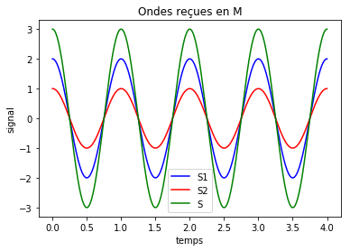

```python
phi=0

#Création d'un tableau contenant les valeurs de s1(t)
s1=[]
for i in range(len(t)):
    s1.append(A1*np.cos(2*np.pi*t[i]/T))

#Création d'un tableau contenant les valeurs de s2(t)
s2=[]
for i in range(len(t)):
    s2.append(A2*np.cos(2*np.pi*t[i]/T+phi))

#création du tableau contenant les valeurs de s(t)
s=[]
for i in range(len(t)):
    s.append(s1[i]+s2[i])

# Affichage de s1(t), s2(t) et s(t)
plt.xlabel("temps")
plt.ylabel("signal")
plt.plot(t,s1,'b-',label='S1')
plt.plot(t,s2,'r-',label='S2')
plt.plot(t,s,'g-',label='S')
plt.title("Ondes reçues en M")
plt.legend()
plt.show()
```

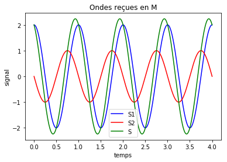

```python
phi=np.pi/2

#Création d'un tableau contenant les valeurs de s1(t)
s1=[]
for i in range(len(t)):
    s1.append(A1*np.cos(2*np.pi*t[i]/T))

#Création d'un tableau contenant les valeurs de s2(t)
s2=[]
for i in range(len(t)):
    s2.append(A2*np.cos(2*np.pi*t[i]/T+phi))

#création du tableau contenant les valeurs de s(t)
s=[]
for i in range(len(t)):
    s.append(s1[i]+s2[i])

# Affichage de s1(t), s2(t) et s(t)
plt.xlabel("temps")
plt.ylabel("signal")
plt.plot(t,s1,'b-',label='S1')
plt.plot(t,s2,'r-',label='S2')
plt.plot(t,s,'g-',label='S')
plt.title("Ondes reçues en M")
plt.legend()
plt.show()
```

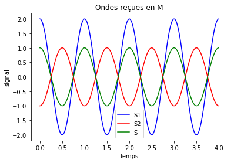

```python
phi=np.pi

#Création d'un tableau contenant les valeurs de s1(t)
s1=[]
for i in range(len(t)):
    s1.append(A1*np.cos(2*np.pi*t[i]/T))

#Création d'un tableau contenant les valeurs de s2(t)
s2=[]
for i in range(len(t)):
    s2.append(A2*np.cos(2*np.pi*t[i]/T+phi))

#création du tableau contenant les valeurs de s(t)
s=[]
for i in range(len(t)):
    s.append(s1[i]+s2[i])

# Affichage de s1(t), s2(t) et s(t)
plt.xlabel("temps")
plt.ylabel("signal")
plt.plot(t,s1,'b-',label='S1')
plt.plot(t,s2,'r-',label='S2')
plt.plot(t,s,'g-',label='S')
plt.title("Ondes reçues en M")
plt.legend()
plt.show()
```

même amplitude et déphasage pi: atténuation maximale  
déphasage nul: atténuation minimale déphasage intermédiaire: atténuation intermédiaire également.

Si l'amplitude est différente, il n'y a pas un signal nul. Elle reste maximale cependant. (Voir le doc"somme-de-deux-signaux-casque-anti-bruit-amplitudes-différentes")</font>

Conclusion : si l'on veut une atténuation maximale, donc un signal nul, il faut créer un anti-bruit de même amplitude que le bruit d'origine avec un déphasage de pi.